# Tidymodels intro

Pablo Benavides-Herrera

2020-04-29

*Based on https://www.tidymodels.org/start/.*

# Build a model

The specific packages to be used here are `broom` and `parsnip`, contained in `tidymodels`.

```r
library(tidyverse)
library(tidymodels)
```

## Import, clean and visualize the data

```r
urchins <-
  read_csv("https://tidymodels.org/start/models/urchins.csv") %>%
  # rename
  setNames(c("food_regime", "initial_volume", "width")) %>%
  # change to factor
  mutate(food_regime = factor(food_regime, levels = c("Initial", "Low", "High")))
urchins
```

| food_regime | initial_volume | width |
| --- | --- | --- |
| Initial | 3.5 | 0.010 |
| Initial | 5.0 | 0.020 |
| Initial | 8.0 | 0.061 |
| Initial | 10.0 | 0.051 |
| Initial | 13.0 | 0.041 |
| Initial | 13.0 | 0.061 |
| Initial | 15.0 | 0.041 |
| Initial | 15.0 | 0.071 |
| Initial | 16.0 | 0.092 |
| Initial | 17.0 | 0.051 |

[output cut: 62 more lines]

One of the very first steps when modelling data is plotting it:

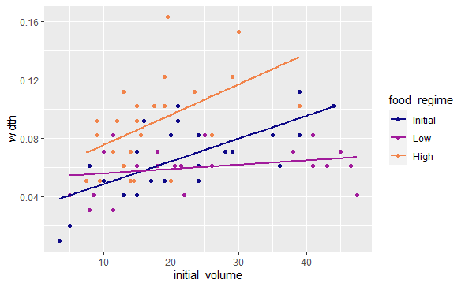

```r
urchins %>%
ggplot(aes(x = initial_volume, y = width,
           group = food_regime, col = food_regime)) +
  geom_point() +
  geom_smooth(method = lm, se = FALSE) +
  scale_color_viridis_d(option = "plasma", end = .7)
```

## Build and fit a model: linear model

We will first do a standard two-way analysis of variance model (ANOVA). We build a model that allows for two-way interactions in **R**, since the slopes appear to be different between food regimes.

```
width ~ initial volume * food_regime
```

We take an ordinary least squares (OLS) approach. How `tidymodels` work is as follows:

1. Specify the functional form of the model using the [`parsnip` package](https://tidymodels.github.io/parsnip/).
   - In this case, we use a linear regression, declaring it with `linear_reg()`.
2. Set the engine with `set_engine()`. This includes the software that can be used to train the model and the estimation method.
   - We use OLS, therefore we set the engine to `lm`.

```r
lm_mod <- linear_reg() %>%
  set_engine("lm")
lm_mod
```

```
Linear Regression Model Specification (regression)

Computational engine: lm
```

We then train the model using the function `fit()` and the specified data and equation.

```r
lm_fit <-
  lm_mod %>%
  fit(width ~ initial_volume * food_regime, data = urchins)
lm_fit
```

```
parsnip model object

Fit time:  0ms

Call:
stats::lm(formula = formula, data = data)

Coefficients:
                   (Intercept)                  initial_volume
                     0.0331216                       0.0015546
                food_regimeLow                 food_regimeHigh
                     0.0197824                       0.0214111
 initial_volume:food_regimeLow  initial_volume:food_regimeHigh
                    -0.0012594                       0.0005254
```

We use `tidy()` in order to retrieve the description of the parameter estimates in a tidy way:

```r
tidy(lm_fit)
```

| term | estimate | std.error | statistic | p.value |
| --- | --- | --- | --- | --- |
| (Intercept) | 0.0331216259 | 0.0096186287 | 3.4434873 | 0.0010020308 |
| initial_volume | 0.0015546403 | 0.0003978337 | 3.9077643 | 0.0002220426 |
| food_regimeLow | 0.0197823628 | 0.0129883393 | 1.5230864 | 0.1325144691 |
| food_regimeHigh | 0.0214111044 | 0.0145317736 | 1.4733993 | 0.1453969848 |
| initial_volume:food_regimeLow | -0.0012593696 | 0.0005101652 | -2.4685525 | 0.0161637663 |
| initial_volume:food_regimeHigh | 0.0005253946 | 0.0007019580 | 0.7484702 | 0.4568356317 |

## Use a model to predict

Suppose that, for a publication, it would be particularly interesting to make a plot of the mean body size for urchins that started the experiment with an initial volume of 20ml.

```r
new_points <- expand.grid(initial_volume = 20,
                          food_regime = c("Initial", "Low", "High"))
new_points
```

| initial_volume | food_regime |
| --- | --- |
| 20 | Initial |
| 20 | Low |
| 20 | High |

We use `predict()` from tidymodels to get our predicted results, as it offers the same syntax, independently of the model used.

```r
mean_pred <- predict(lm_fit, new_data = new_points)
mean_pred
```

| .pred |
| --- |
| 0.06421443 |
| 0.05880940 |
| 0.09613343 |

To get the confidence intervals, whe specify `type = "conf_int` whitin `predict()`.

```r
conf_int_pred <- predict(lm_fit,
                         new_data = new_points,
                         type = "conf_int")
conf_int_pred
```

| .pred_lower | .pred_upper |
| --- | --- |
| 0.05549934 | 0.07292952 |
| 0.04986251 | 0.06775629 |
| 0.08696233 | 0.10530453 |

To plot our results, we first need to combine all these results and the original data into a single tibble.

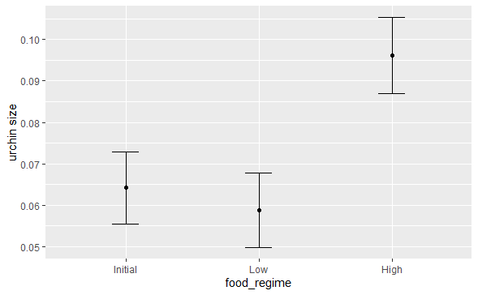

```r
# Combine data
plot_data <-
  new_points %>%
  bind_cols(mean_pred) %>%
  bind_cols(conf_int_pred)

# and plot:
ggplot(plot_data, aes(x = food_regime)) +
  geom_point(aes(y = .pred)) +
  geom_errorbar(aes(ymin = .pred_lower,
                    ymax = .pred_upper),
                width = .2) +
  labs(y = "urchin size")
```

## Model with a different engine: Bayesian Analysis